# Exploring GPS data

Checking over GPS data for accuracy of speed, etc.

Author

David O’Sullivan

Published

July 16, 2024

**Update History**

| Date | Changes |
| --- | --- |
| 2024-07-16 | Initial post. |

```r
library(dplyr)
library(tidyr)
library(janitor)
library(stringr)
library(here)
library(lubridate)
library(sf)
library(terra)
library(tmap)
library(ggplot2)
library(zoo) # useful for serial data

# simple function to read GPS CSV as a sf dataset
get_gps_data_as_sf <- function(fname) {
  read.csv(fname) |>
    clean_names() |>
    st_as_sf(coords = c("longitude", "latitude"), crs = 4326, remove = FALSE) |>
    st_transform(crs = 3031)
}
```

These notes explore the usefulness, accuracy etc. of the provided GPS data.

Of particular interest is the asymmetry or not of movement speeds with respect to slope, given the salience of this for ‘hiking functions’. It is possible in a largely ‘unpathed’ environment that the asymmetry is limited (see e.g. Rees 2004[^1])

We use just one of the datasets to explore general characteristics. Remove a meaningless column `x` and do a little bit of cleanup on the `rcr` and date and time columns.

```r
gps_data <- get_gps_data_as_sf(str_glue(
  "{here()}/_data/GPS-1516Season-MiersValley/Fraser-FINAL.csv")) |>
    select(-x) |>
    mutate(rcr = as.logical(rcr),
           date_time = ymd_hms(paste(date, time)))
```

## Exploration of the data

A summary of the data suggests that there are some data rows that should be ignored.

```r
summary(gps_data)
```

```
     index        rcr              date               time
 Min.   :   1   Mode:logical   Length:7323        Length:7323
 1st Qu.:1832   TRUE:7304      Class :character   Class :character
 Median :3662   NA's:19        Mode  :character   Mode  :character
 Mean   :3662
 3rd Qu.:5492
 Max.   :7323
    valid              latitude          n_s              longitude
 Length:7323        Min.   :-78.12   Length:7323        Min.   :163.7
 Class :character   1st Qu.:-78.11   Class :character   1st Qu.:163.8
 Mode  :character   Median :-78.10   Mode  :character   Median :163.8
                    Mean   :-78.10                      Mean   :163.9
                    3rd Qu.:-78.10                      3rd Qu.:163.9
                    Max.   :-78.09                      Max.   :164.2
     e_w               height_m       speed_km_h           pdop
 Length:7323        Min.   :-23.1   Min.   :  0.000   Min.   : 0.98
 Class :character   1st Qu.:102.1   1st Qu.:  0.255   1st Qu.: 1.14
 Mode  :character   Median :110.8   Median :  0.496   Median : 1.19
                    Mean   :180.1   Mean   :  1.604   Mean   : 1.27
                    3rd Qu.:165.7   3rd Qu.:  2.241   3rd Qu.: 1.24
                    Max.   :636.9   Max.   :209.555   Max.   :13.76
      hdop              vdop        nsat_used_view       distance_m
 Min.   : 0.6100   Min.   :0.7600   Length:7323        Min.   :    0.00
 1st Qu.: 0.7400   1st Qu.:0.8600   Class :character   1st Qu.:    1.38
 Median : 0.7900   Median :0.8900   Mode  :character   Median :    2.78
 Mean   : 0.7977   Mean   :0.9756                      Mean   :   21.73
 3rd Qu.: 0.8400   3rd Qu.:0.9200                      3rd Qu.:   14.99
 Max.   :13.7200   Max.   :4.7100                      Max.   :74486.45
          geometry      date_time
 POINT        :7323   Min.   :2016-01-13 16:28:31.07
 epsg:3031    :   0   1st Qu.:2016-01-15 16:43:27.00
 +proj=ster...:   0   Median :2016-01-19 12:46:32.00
                      Mean   :2016-01-19 01:37:06.72
                      3rd Qu.:2016-01-22 08:39:45.00
                      Max.   :2016-01-23 15:16:47.00
```

A speed of > 200km/h was clearly not achieved on foot! Similarly an elapsed distance between 1/30Hz fixes of 74km was not on foot either.

The GPS dilution of precision measures for horizontal and vertical position (**hdop** and **vdop**) are mostly within the ‘good’ range (<1) with some outliers. The 3D positions (**pdop**) are not as good, but are also generally considered reliable (<5). Inspection of a quick map of the data suggests helicopter movement or similar for some ‘singleton’ isolated observations:

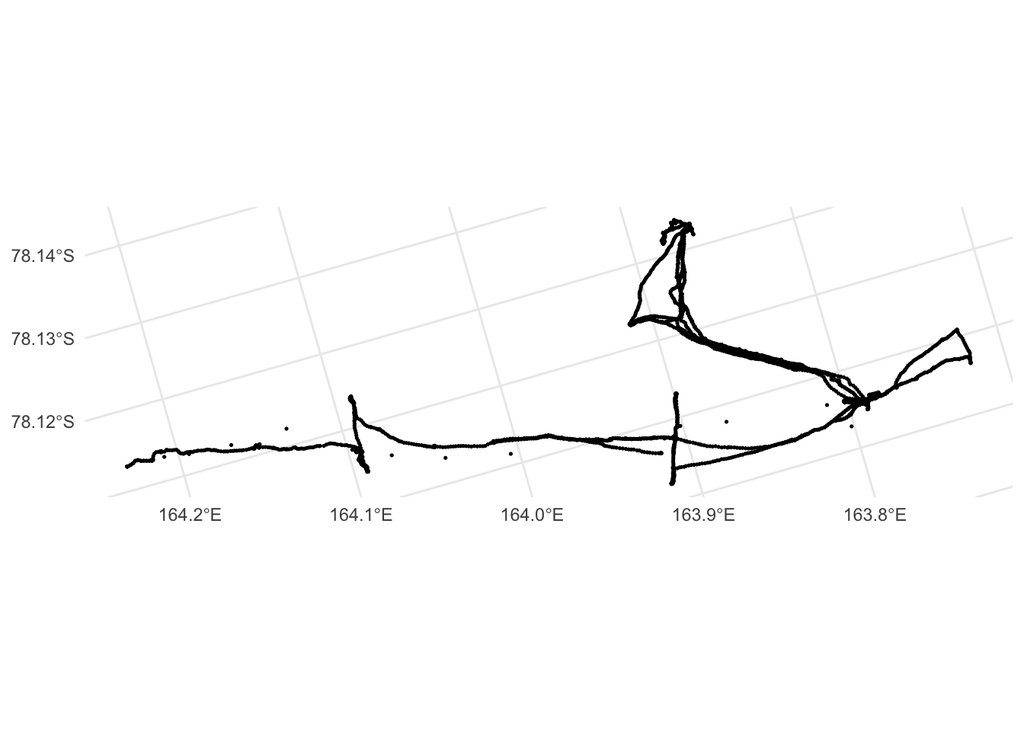

```r
ggplot(gps_data) +
  geom_sf(size = 0.25) +
  theme_minimal()
```

This being the case it seems reasonable to remove observations with clearly unreasonable speed estimates, assuming that these result from use of other forms of transport. However, before doing so, we augment the data with additional estimates of speed, distance, etc. calculated from consecutive fixes (it is not advisable to remove any fixes before making these estimates).

## Sanity checking the GPS estimates of speed, distance, and height

Before applying that potentially simplistic cleaning of the data, it is also reasonable to sanity check the speed, distance, and height estimates in the GPS data. First we obtain height data from a 10m DEM.

```r
xy <- gps_data |>
  st_coordinates() |>
  as_tibble()

dem <- rast(str_glue("{here()}/_data/input/dry-valleys-10m.tif"))
# and useful for later will be a hillshade
slope <- dem |> terra::terrain("slope", unit = "radians")
aspect <- dem |> terra::terrain("aspect", unit = "radians")
hillshade <- shade(slope, aspect)
TRI <- dem |> terra::terrain("TRI")

heights_from_dem <- dem |>
  terra::extract(xy, method = "simple") |>
  select(2)

slope_from_dem <- slope |>
  terra::extract(xy, method = "simple") |>
  select(2)

TRI_from_dem <- TRI |>
  terra::extract(xy, method = "simple") |>
  select(2)

xy <- xy |>
  bind_cols(heights_from_dem) |>
  rename(Z = `dry-valleys-10m`) |>
  bind_cols(slope_from_dem) |>
  mutate(dem_slope_percent = tan(slope) * 100) |>
  select(-slope) |>
  bind_cols(TRI_from_dem)

gps_data_plus <- gps_data |>
  bind_cols(xy)
```

Now calculate estimates of distance, change in elevation, and slope between observations, from these numbers and from the GPS data.

```r
gps_data_plus <- gps_data_plus |>
  mutate(dx = as.numeric(diff(as.zoo(X), na.pad = TRUE)),
         dy = as.numeric(diff(as.zoo(Y), na.pad = TRUE)),
         dz = as.numeric(diff(as.zoo(Z), na.pad = TRUE)),
         dh = as.numeric(diff(as.zoo(height_m), na.pad = TRUE)),
         dt = as.numeric(diff(as.zoo(date_time), na.pad = TRUE)),
         dxy = sqrt(dx^ 2 + dy ^ 2),
         dxyz = sqrt(dx ^ 2 + dy ^ 2 + dz ^ 2),
         dxyh = sqrt(distance_m ^ 2 + dh ^ 2),
         slope_h = dh / distance_m * 100,
         slope_z = dz / dxy * 100,
         speedxy = dxy / dt * 3600 / 1000, speedxyz = dxyz / dt * 3600 / 1000)
```

Now some comparisons.

### Distance estimates

The `distance_m` estimates in the provided data are a little higher than the manually calculated point to point straight line distances between fixes. However, examination of sequences of data show the two time series are well aligned (below). Differences may be due to filtering applied by the GPS unit, although this is not well documented.

*In any case, the GPS `distance_m` variable seems safe for use in further analysis.*

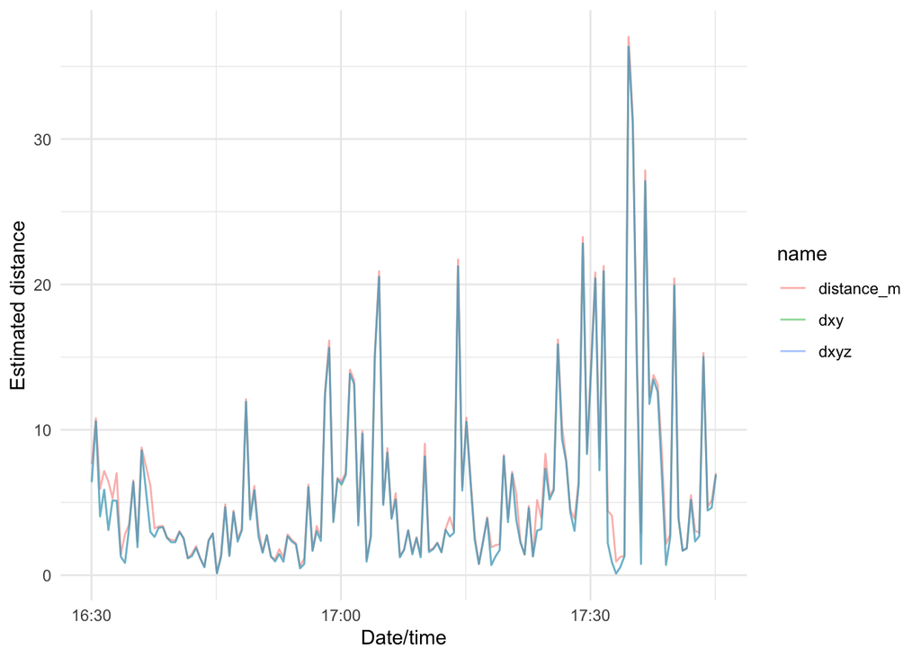

```r
gps_data_plus |>
  filter(dt == 30) |>
  slice(2:151) |>
  pivot_longer(cols = c(distance_m, dxy, dxyz)) |>
  ggplot() +
  geom_line(aes(x = date_time, y = value, colour = name, group = name), alpha = 0.5) +
  xlab("Date/time") + ylab("Estimated distance") +
  theme_minimal()
```

### Speed estimates

Differences in the speed estimates are more pronounced:

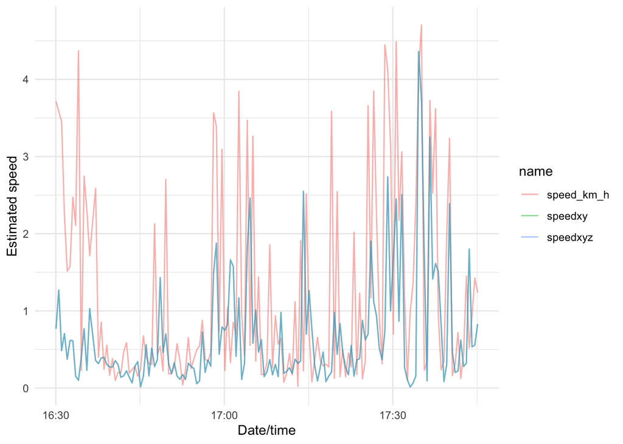

```r
gps_data_plus |>
  filter(dt == 30) |>
  slice(2:151) |>
  pivot_longer(cols = c(speed_km_h, speedxy, speedxyz)) |>
  ggplot() +
  geom_line(aes(x = date_time, y = value, colour = name, group = name), alpha = 0.5) +
  xlab("Date/time") + ylab("Estimated speed") +
  theme_minimal()
```

The provided speed estimates are generally higher although there is some alignment between the time series, insofar as extended periods of low speeds tend to line up.

A likely reason for the differences is that in a 30 second period (the usual interval between fixes) an individual may move in many directions so that the direct point to point distance between fixes is less than might be expected based on the recorded speed. So, for example, in the above chart between 16:30 and 16:40 the person was moving not in straight lines, where in the following 10 minutes they were moving in relatively straight lines. We can test this theory, at least qualitatively, by calculating a *sinuosity* estimate between fixes.

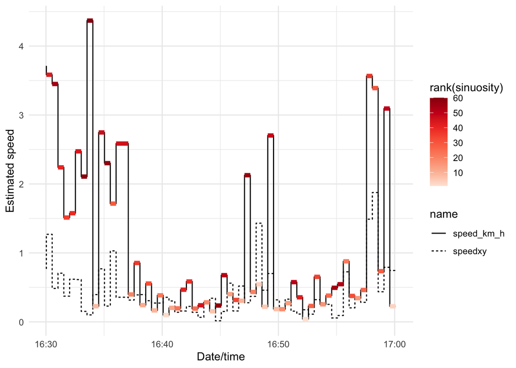

```r
sinuosity <- gps_data_plus |>
  filter(dt == 30) |>
  slice(2:61) |>
  # select(date_time, speed_km_h, dxy, speedxy) |>
  mutate(sinuosity = speed_km_h / 120 / distance_m,
         date_time_start = lag(date_time))

speeds <- sinuosity |>
  pivot_longer(cols = c(speed_km_h, speedxy))

ggplot(speeds) +
  geom_step(aes(x = date_time, y = value, group = name, linetype = name),
            direction = "vh", lwd = 0.5) +
  geom_segment(data = sinuosity,
               aes(x = date_time_start, xend = date_time,
                   y = speed_km_h, colour = rank(sinuosity)), lwd = 2) +
  scale_colour_distiller(palette = "Reds", direction = 1) +
  xlab("Date/time") + ylab("Estimated speed") +
  theme_minimal()
```

Since the estimated sinuosity here is based only on the GPS estimated speed and point to point distances, that it is generally highest when the difference between the GPS reported speed `speed_km_h` and the manually estimated speed `speedxy` is largest supports the assumption that the GPS is reporting speed using satellite carrier signal doppler effects.

*Based on this check, the GPS `speed_km_h` variable seems reasonable to use for hiking function estimation.*

### GPS height and elevation from the DEM

Again, there are differences between heights recorded by the GPS units, and heights extracted from the 10m DEM. Again, it is difficult to know why these might occur, although there is a clear correlation between the two. There is no obvious correlation with surface roughness (TRI), for example, or with the vertical dilution of precision (`vdop`).

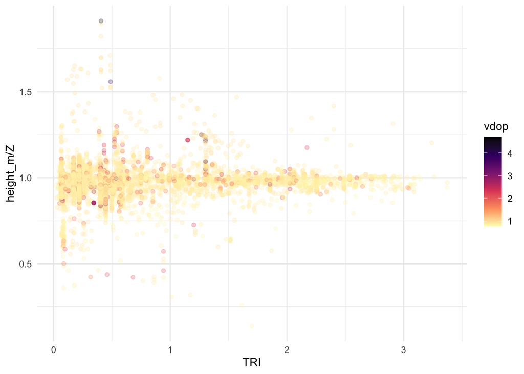

```r
ggplot(gps_data_plus |>
         filter(dt == 30, distance_m < 60, height_m > 0, Z > 0)) +
  geom_point(aes(x = TRI, y = height_m / Z, colour = vdop), alpha = 0.25) +
  scale_colour_viridis_c(option = "A", direction = -1) +
  theme_minimal()
```

Pragmatically, in the next section, I find that the relationship between slope and speed based on the GPS readings is much better behaved than that derived from the speed and elevation extracted from the DEM. The reason it can be used to estimate slope in that context is divergences between `height_m` (from the GPS) and `Z` (from the DEM) are serially correlated, so that estimates of slope derived from consecutive data points are useable for that purpose.

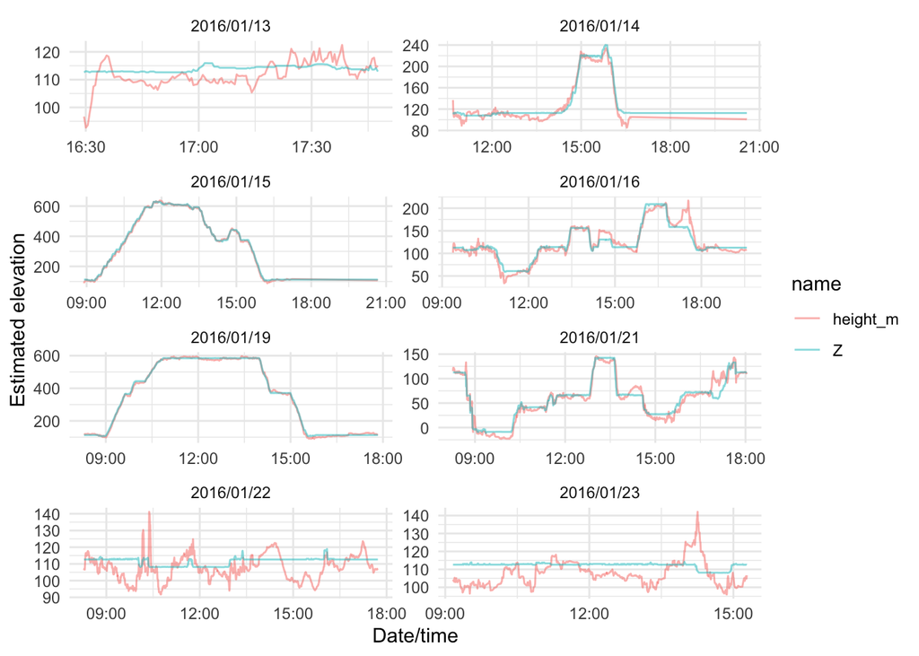

```r
gps_data_plus |>
  filter(dt == 30) |>
  pivot_longer(cols = c(height_m, Z)) |>
  ggplot() +
  geom_line(aes(x = date_time, y = value, colour = name, group = name), alpha = 0.5) +
  xlab("Date/time") + ylab("Estimated elevation") +
  facet_wrap(~ date, scales = "free", ncol = 2) +
  theme_minimal()
```

*Again, it seems reasonable to use the GPS unit reported heights for estimation of hiking functions.* The main impact on the analysis in the next section is to introduce noise into the slope at low values.

## A hiking function

A hiking function relates slope of the land to speed at which it is traversed. Using the GPS unit reported speed and slope derived from GPS unit reported distance and height, locally estimated scatter plot smoothing yields an expected approximately Gaussian curve with the peak speed at or close to 0 slope.

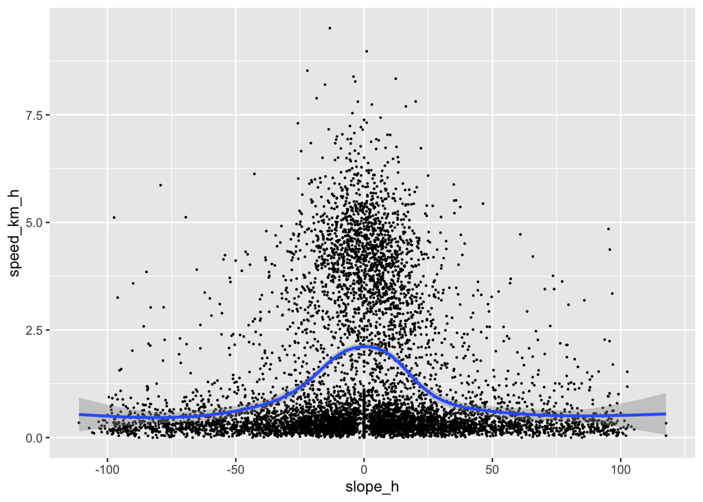

```r
gps_data_plus |>
  filter(dt == 30, speed_km_h < 10, !is.na(slope_h)) |>
  ggplot(aes(x = slope_h, y = speed_km_h)) +
  geom_point(size = 0.25) +
  geom_smooth(aes(x = slope_h, y = speed_km_h))
```

```r
model <- loess(speed_km_h ~ slope_h, data = gps_data_plus)
```

### Removing uninteresting sequences to improve hiking function estimation

Many data in the above plot are probably from ‘milling about’ in breaks, at camp, or around experiments, rather than while on the move. The most effective way to remove such sections from the data is likely based on the density of fixes.

However, this should be carried out across all GPS datasets not on each individually.

## Conclusion: a reasonable GPS file cleaning function

Based on this exploration, GPS data need to be processed as follows (note that no initial conversion to a spatial format is required at this stage, since none of the added spatial data introduced above is required).

- Read raw data from CSV.
- Clean names with `janitor::clean_names`.
- Remove meaningless variable `x`.
- Add a `name` reflecting the id of the person whose data is.
- Augment data with `dt` (time interval between fixes), dh`(height change between fixes), and`slope_h` (estimated slope between fixes).
- Remove data outside expected latitudinal range (> -78 latitude).
- Remove fixes with high estimated speeds (>~ 10km/h).
- Remove fixes with long estimated distances (>~ 60m).
- Identify breaks in the series where `dt != 30` and tag subsets of the data accordingly.
- Drop NAs and any rows where `dt != 30`.

This gives us the following function.

```r
get_cleaned_gps_data <- function(fname) {
  read.csv(fname) |>
    clean_names() |>
    select(-x) |>
    mutate(name = person,
           rcr = as.logical(rcr),
           date_time = ymd_hms(paste(date, time)),
           dh = as.numeric(diff(as.zoo(height_m), na.pad = TRUE)),
           dxyh = sqrt(distance_m ^ 2 + dh ^ 2),
           slope_h = dh / distance_m * 100) |>
    filter(latitude <= -78,
           speed_km_h < 10,
           distance_m < 60,
           hdop < 5,
           vdop < 5,
           pdop < 5) |>
    mutate(dt = as.numeric(diff(as.zoo(date_time), na.pad = TRUE)),
           break_in_series = is.na(dt) | dt != 30,
           subset = cumsum(break_in_series),
           subset = str_c(person, str_pad(subset, width = 3, side = "left", pad = "0"))) |>
    filter(dt == 30) |>
    select(-break_in_series) |>
    drop_na()
}
```

which can be called as below:

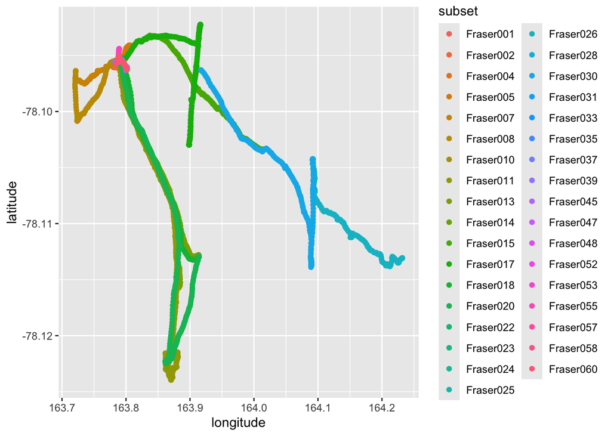

```r
person <- "Fraser"
fname <- str_glue("{here()}/_data/GPS-1516Season-MiersValley/{person}-FINAL.csv")

get_cleaned_gps_data(fname) |>
  ggplot() +
  geom_point(aes(x = longitude, y = latitude, colour = subset))
```

## Footnotes

[^1]: Rees WG. 2004. Least-cost paths in mountainous terrain. *Computers & Geosciences* **30**(3) 203–209. doi: 10.1016/j.cageo.2003.11.001.